# LAB_8_9

name *Lakshay Soni*

student_ID *8888349*

```python
import pandas as pd
import tensorflow as tf
from tensorflow.keras.datasets import mnist
from tensorflow import keras
from tensorflow.keras import layers
from sklearn.model_selection import train_test_split
from sklearn.metrics import accuracy_score, precision_score, recall_score, f1_score
from sklearn.preprocessing import StandardScaler
from keras.models import Sequential
from keras.layers import Dense
from keras.optimizers import Adam
```

```
2024-03-16 20:52:33.090058: I tensorflow/core/platform/cpu_feature_guard.cc:210] This TensorFlow binary is optimized to use available CPU instructions in performance-critical operations.
To enable the following instructions: AVX2 FMA, in other operations, rebuild TensorFlow with the appropriate compiler flags.
```

Get the data from Kaggle. See image below. Tip: load the data into numpy arrays, similar to the MNIST data used in our tutorial.

READING THE DATAFRAME

```python
train_data = pd.read_csv('/Users/lakshay/Desktop/LAB_ALL/CSCN8010-Lab-8888349/fashion-mnist_train.csv')
test_data = pd.read_csv('/Users/lakshay/Desktop/LAB_ALL/CSCN8010-Lab-8888349/fashion-mnist_test.csv')
```

```python
# Convert DataFrames to numpy arrays
X_train = train_data.iloc[:, 1:].values.astype('float32')  # Features
y_train = train_data.iloc[:, 0].values.astype('int32')     # Labels

X_test = test_data.iloc[:, 1:].values.astype('float32')    # Features
y_test = test_data.iloc[:, 0].values.astype('int32')        # Labels
```

```python
# Normalize the features
X_train = X_train / 255.0
X_test = X_test / 255.0
```

Especially when working with variables of varying scales, normalization is a crucial preprocessing step that enhances the performance and stability of machine learning models.

```python
# Reshape the features
X_train = X_train.reshape(-1, 28, 28, 1)
X_test = X_test.reshape(-1, 28, 28, 1)
```

For the neural network to handle the data efficiently and ensure that the input data you provide fits the required format of your model, you must reshape the data.

```python
# Print the shapes of the arrays
print("X_train shape:", X_train.shape)
print("y_train shape:", y_train.shape)
print("X_test shape:", X_test.shape)
print("y_test shape:", y_test.shape)
```

```
X_train shape: (60000, 28, 28, 1)
y_train shape: (60000,)
X_test shape: (10000, 28, 28, 1)
y_test shape: (10000,)
```

The form would represent a single grayscale channel if the image were grayscale (28, 28, 1). A picture with a height of 28 pixels, a width of 28 pixels, and three RGB colour channels is indicated when you see the shape (28, 28, 3).

```python
# Defining the class names based on the info gathered
class_names = ['T-shirt/top', 'Trouser', 'Pullover', 'Dress', 'Coat', 'Sandal', 'Shirt', 'Sneaker', 'Bag', 'Ankle boot']
```

Run Great EDA (1 point). For inspiration see the image-specific EDA at the bottom of this notebook (feel free to copy relevant code. This was taken from notebooks of students of this course). Also, feel free to reference code from Kaggle (add links). Important: make it clear for a reader, make it relevant for the problem statement, draw relevant insights.

# ORIGIN#

The MNIST dataset was created by Yann LeCun, Corinna Cortes, and Christopher J.C. Burgess.

The test set has 10,000 photos, whereas the training set contains 60000. A picture's dimensions are 28 pixels wide by 28 pixels high. An image in grayscale (one channel for intensity) is indicated by the last dimension of 1.

The organized data is prepared for model training. It is possible to assess the model's performance on untested data thanks to the division of the sets into training and testing sets.

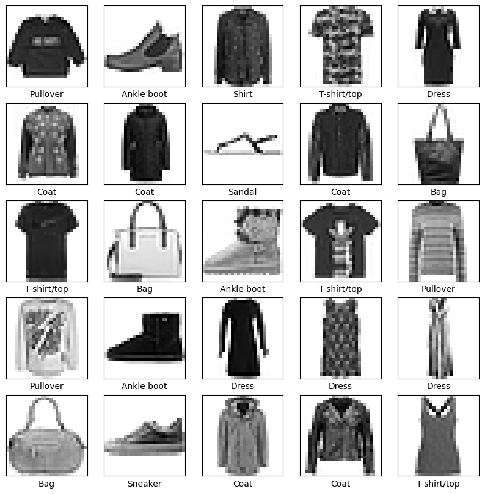

```python
import matplotlib.pyplot as plt
import seaborn as sns
import numpy as np

plt.figure(figsize=(10, 10))
for i in range(25):
    plt.subplot(5, 5, i + 1)
    plt.xticks([])
    plt.yticks([])
    plt.grid(False)
    plt.imshow(X_train[i], cmap=plt.cm.binary)
    plt.xlabel(class_names[y_train[i]])
plt.show()
```

Despite the image's resemblance to the MNIST dataset of handwritten digits, it is more likely to have come from the Fashion-MNIST dataset, a collection of grayscale apparel photos with 10,000 testing and 60,000 training samples.

Multiple grayscale clothing pieces, probably 28 by 28 pixels, make up the image.

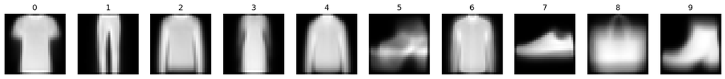

```python
fig, axes = plt.subplots(1, 10, figsize=(20, 2))
for digit in range(10):
    digit_indices = np.where(y_train.astype('int8') == digit)[0]
    avg_image = np.mean(X_train[digit_indices], axis=0).reshape(28, 28)
    axes[digit].imshow(avg_image, cmap='gray')
    axes[digit].set_title(str(digit))
    axes[digit].axis('off')
plt.show()
```

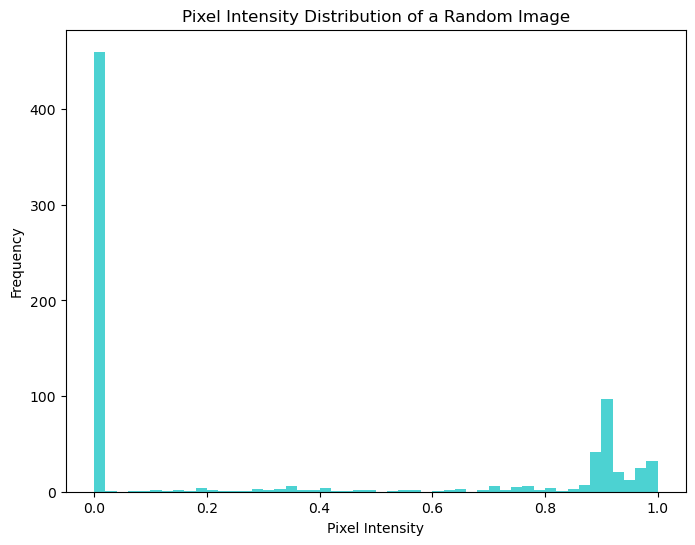

```python
random_image_index = np.random.randint(0, len(X_train))
image_flat = X_train[random_image_index].flatten()

plt.figure(figsize=(8, 6))
plt.hist(image_flat, bins=50, color='c', alpha=0.7)
plt.title('Pixel Intensity Distribution of a Random Image')
plt.xlabel('Pixel Intensity')
plt.ylabel('Frequency')
plt.show()
```

Define and Train a fully-connected feedforward neural network of your choice using Keras and Tensorflow. (1 point)

```python
X_train, X_val, y_train, y_val = train_test_split(X_train, y_train, test_size=0.2, random_state=42)
```

We are giving split because need to stick towards performance of model on validation set as it can help us avoid overfitting.

definig model and compiling

```python
X_train_flat = X_train.reshape(X_train.shape[0], -1)
X_val_flat = X_val.reshape(X_val.shape[0], -1)
X_test_flat = X_test.reshape(X_test.shape[0], -1)

# Check the shape
print("X_train_flat shape:", X_train_flat.shape)
print("X_val_flat shape:", X_val_flat.shape)
print("X_test_flat shape:", X_test_flat.shape)
```

```
X_train_flat shape: (48000, 784)
X_val_flat shape: (12000, 784)
X_test_flat shape: (10000, 784)
```

To enable efficient processing and analysis, machine learning models require an input format that differs from the inherent structure of images. This is where data reshapimg is.

```python
# Defining
model = Sequential([
    Dense(128, input_shape=(784,), activation='relu'),
    Dense(64, activation='relu'),
    Dense(10, activation='softmax')
])

# Compiling
model.compile(optimizer='adam', loss='sparse_categorical_crossentropy', metrics=['accuracy'])

# Train the model input
history = model.fit(X_train_flat, y_train, epochs=10, batch_size=128, validation_data=(X_val_flat, y_val))
loss, accuracy = model.evaluate(X_test_flat, y_test)
print(f'Test loss: {loss}')
print(f'Test accuracy: {accuracy}')
```

```
375/375 ━━━━━━━━━━━━━━━━━━━━ 5s 10ms/step - accuracy: 0.7333 - loss: 0.7813 - val_accuracy: 0.8401 - val_loss: 0.4441
375/375 ━━━━━━━━━━━━━━━━━━━━ 4s 10ms/step - accuracy: 0.8529 - loss: 0.4192 - val_accuracy: 0.8561 - val_loss: 0.4011
375/375 ━━━━━━━━━━━━━━━━━━━━ 3s 9ms/step - accuracy: 0.8669 - loss: 0.3747 - val_accuracy: 0.8626 - val_loss: 0.3693
375/375 ━━━━━━━━━━━━━━━━━━━━ 4s 6ms/step - accuracy: 0.8791 - loss: 0.3384 - val_accuracy: 0.8690 - val_loss: 0.3513
375/375 ━━━━━━━━━━━━━━━━━━━━ 3s 8ms/step - accuracy: 0.8857 - loss: 0.3211 - val_accuracy: 0.8700 - val_loss: 0.3487
375/375 ━━━━━━━━━━━━━━━━━━━━ 4s 5ms/step - accuracy: 0.8897 - loss: 0.3020 - val_accuracy: 0.8710 - val_loss: 0.3440
375/375 ━━━━━━━━━━━━━━━━━━━━ 3s 9ms/step - accuracy: 0.8948 - loss: 0.2863 - val_accuracy: 0.8798 - val_loss: 0.3203
375/375 ━━━━━━━━━━━━━━━━━━━━ 2s 7ms/step - accuracy: 0.8998 - loss: 0.2749 - val_accuracy: 0.8768 - val_loss: 0.3402
375/375 ━━━━━━━━━━━━━━━━━━━━ 2s 4ms/step - accuracy: 0.8991 - loss: 0.2710 - val_accuracy: 0.8800 - val_loss: 0.3381
375/375 ━━━━━━━━━━━━━━━━━━━━ 2s 4ms/step - accuracy: 0.9053 - loss: 0.2550 - val_accuracy: 0.8832 - val_loss: 0.3163
313/313 ━━━━━━━━━━━━━━━━━━━━ 1s 2ms/step - accuracy: 0.8827 - loss: 0.3163
Test loss: 0.3130054175853729
Test accuracy: 0.8842999935150146
```

The neural network showed it could learn from the training set after ten epochs, with a robust training accuracy of roughly 90%. The validation accuracy of about 88% highlights the model's ability to generalize novel, untested inputs. The decrease in training loss over epochs indicates effective parameter optimization, resulting in higher prediction accuracy. Evaluation on an independent test set yielded a remarkable accuracy of 88%, confirming the model's ability to make correct predictions on previously data.

*Evaluate the model using the validation dataset. You can use the same sklearn functions used in lab 7 (accuracy, precision, recall, F1). Feel free to expand (2 points).*

```python
# Predict probabilities for the validation set
y_val_prob = model.predict(X_val_flat)
y_val_pred = np.argmax(y_val_prob, axis=1)

# Calculate accuracy
accuracy = accuracy_score(y_val, y_val_pred)

# Calculate precision
precision = precision_score(y_val, y_val_pred, average='macro')

# Calculate recall
recall = recall_score(y_val, y_val_pred, average='macro')

# Calculate F1-score
f1 = f1_score(y_val, y_val_pred, average='macro')

print(f'Accuracy: {accuracy}')
print(f'Precision: {precision}')
print(f'Recall: {recall}')
print(f'F1 Score: {f1}')
```

```
375/375 ━━━━━━━━━━━━━━━━━━━━ 1s 2ms/step
Accuracy: 0.8831666666666667
Precision: 0.8854817096227257
Recall: 0.8844724494649057
F1 Score: 0.8844844790292669
```

Recall (0.88): Recall, or sensitivity, measures the model's capacity to capture all positive cases. The high recall of 88% implies a low rate of false negatives, which is significant in applications that require all positives to be identified.

F1 Rating (0.88): The F1 score balances precision and recall, resulting in a harmonic mean. The model achieves a substantial trade-off between accuracy and recall, as seen by its F1 score of 88%.

*Run the model on the test set, and provide clear and relevant conclusions (1 point)*

```python
# Predict probabilities for the test set
y_test_prob = model.predict(X_test_flat)
y_test_pred = np.argmax(y_test_prob, axis=1)

# Calculate accuracy
accuracy = accuracy_score(y_test, y_test_pred)

# Calculate precision
precision = precision_score(y_test, y_test_pred, average='macro')

# Calculate recall
recall = recall_score(y_test, y_test_pred, average='macro')

# Calculate F1-score
f1 = f1_score(y_test, y_test_pred, average='macro')

print(f'Test Accuracy: {accuracy}')
print(f'Test Precision: {precision}')
print(f'Test Recall: {recall}')
print(f'Test F1 Score: {f1}')
```

```
 28/313 ━━━━━━━━━━━━━━━━━━━━ 1s 4ms/step313/313 ━━━━━━━━━━━━━━━━━━━━ 1s 2ms/step
Test Accuracy: 0.8843
Test Precision: 0.8858693455445132
Test Recall: 0.8843
Test F1 Score: 0.884521199715748
```

Since precision and recall are near each other, these results suggest that the model has generally established a satisfactory alternative between the two. The F1 score of 88% combines precision and recall into a single statistic, offering a balanced assessment of the model's performance.

With high accuracy, balanced precision, and recall values, the model has demonstrated strong performance on the Fashion MNIST dataset, suggesting its efficacy in categorizing fashion photos.

```python
# new threshold
new_threshold = 0.8

# Predict probabilities
y_test_prob = model.predict(X_test_flat)

# probabilities using the new threshold
y_test_pred = np.argmax(y_test_prob, axis=1)
y_test_pred[y_test_prob[:, 5] < new_threshold] = -1

# Calculate precision for class '5' with the new threshold
precision_class_5 = precision_score(y_test, y_test_pred, labels=[5], average='macro')

print(f'Precision for class "5" with threshold {new_threshold}: {precision_class_5}')
```

```
313/313 ━━━━━━━━━━━━━━━━━━━━ 1s 2ms/step
Precision for class "5" with threshold 0.8: 0.983957219251337
```

When minimizing false positives, a high precision value is valid. Here, at a higher confidence threshold, the model demonstrates vital precision for class "5", demonstrating high confidence in its positive forecasts. An optimistic 98% of forecasts are accurate.

```python
# Set the new threshold
new_threshold = 0.2

# Predict probabilities for the test set
y_test_prob = model.predict(X_test_flat)

# Convert probabilities to class labels using the new threshold
y_test_pred = np.argmax(y_test_prob, axis=1)
y_test_pred[y_test_prob[:, 5] < new_threshold] = -1

# Calculate recall for class '5' with the new threshold
recall_class_5 = recall_score(y_test, y_test_pred, labels=[5], average='macro')

print(f'Recall for class "5" with threshold {new_threshold}: {recall_class_5}')
```

```
313/313 ━━━━━━━━━━━━━━━━━━━━ 1s 2ms/step
Recall for class "5" with threshold 0.2: 0.949
```

*LAB 9 - Avoiding Overfitting by Saving a Model*

Step 3: Instead of just one neural network, explore 3 different neural networks (by changing any hyperparameter of your choice) (3 points).

```python
from tensorflow.keras.models import Sequential
from tensorflow.keras.layers import Dense
from tensorflow.keras.optimizers import Adam

def create_model(learning_rate=0.001, batch_size=128):
    model = Sequential([
        Dense(128, input_shape=(784,), activation='relu'),
        Dense(64, activation='relu'),
        Dense(10, activation='softmax')
    ])

    optimizer = Adam(learning_rate=learning_rate)
    model.compile(optimizer=optimizer, loss='sparse_categorical_crossentropy', metrics=['accuracy'])

    return model
```

Deefining graph plotting for training and loss

```python
def plot_training_history(history):
    plt.figure(figsize=(12, 6))
    plt.subplot(1, 2, 1)
    plt.plot(history.history['accuracy'])
    plt.plot(history.history['val_accuracy'])
    plt.title('Model Accuracy')
    plt.ylabel('Accuracy')
    plt.xlabel('Epoch')
    plt.legend(['Train', 'Validation'], loc='upper left')

    plt.subplot(1, 2, 2)
    plt.plot(history.history['loss'])
    plt.plot(history.history['val_loss'])
    plt.title('Model Loss')
    plt.ylabel('Loss')
    plt.xlabel('Epoch')
    plt.legend(['Train', 'Validation'], loc='upper left')
    plt.show()
```

Defining 3 neural networks

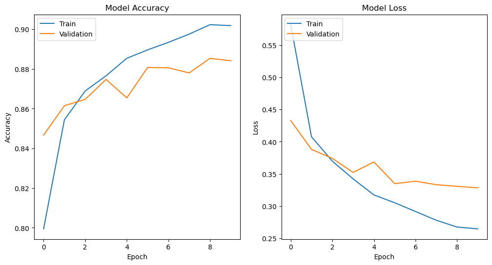

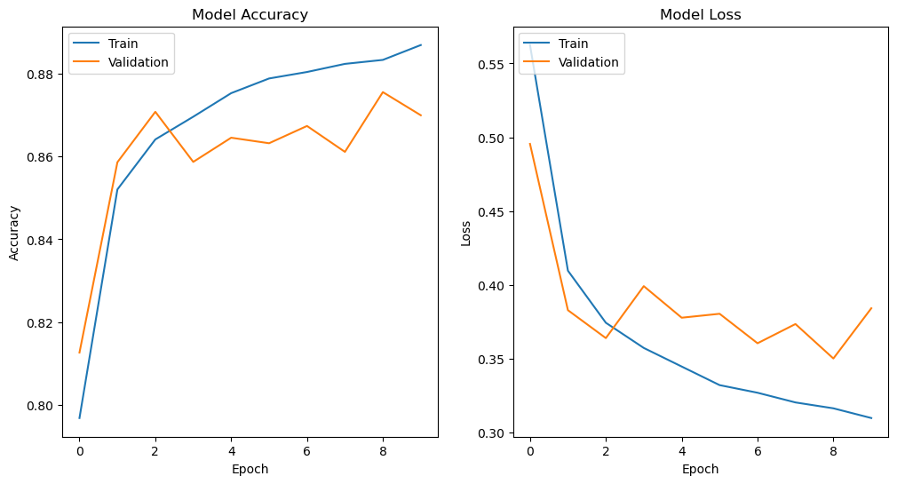

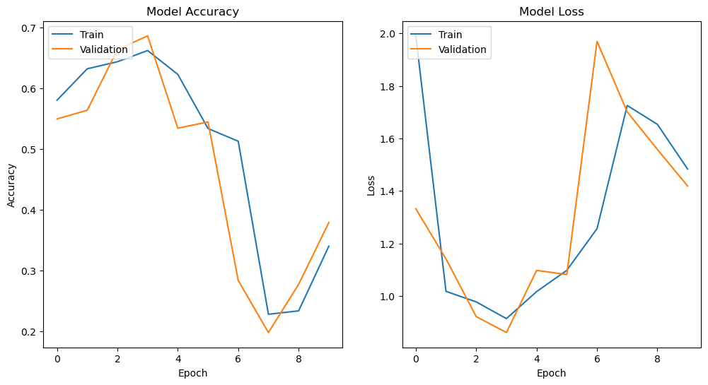

```python
# Model 1
model1 = create_model(learning_rate=0.001, batch_size=128)
history1 = model1.fit(X_train_flat, y_train, epochs=10, batch_size=128, validation_data=(X_val_flat, y_val), verbose=0)
plot_training_history(history1)

# Model 2
model2 = create_model(learning_rate=0.01, batch_size=128)
history2 = model2.fit(X_train_flat, y_train, epochs=10, batch_size=128, validation_data=(X_val_flat, y_val), verbose=0)
plot_training_history(history2)

# Model 3
model3 = create_model(learning_rate=0.1, batch_size=128)
history3 = model3.fit(X_train_flat, y_train, epochs=10, batch_size=128, validation_data=(X_val_flat, y_val), verbose=0)
plot_training_history(history3)
```

```python
def find_best_epoch(history):
    val_loss = history.history['val_loss']
    min_val_loss = min(val_loss)
    best_epoch = val_loss.index(min_val_loss) + 1
    return best_epoch
```

```python
# Find the best epoch for each model
best_epoch1 = find_best_epoch(history1)
best_epoch2 = find_best_epoch(history2)
best_epoch3 = find_best_epoch(history3)

# weights at the best epoch for each model
best_weights1 = history1.model.get_weights()
best_weights2 = history2.model.get_weights()
best_weights3 = history3.model.get_weights()
```

Evaluating best model

```python
model1.set_weights(best_weights1)
print("Best weights for Model 1:")
print(best_weights1[0])
```

```
Best weights for Model 1:
[[ 0.04156927 -0.1685271   0.02787426 ...  0.01731272  0.25184628
  -0.06746031]
 [ 0.1408079  -0.18478315  0.01437539 ... -0.09688208  0.30556554
   0.0033018 ]
 [ 0.07565776 -0.05869314  0.04310301 ...  0.22909012 -0.03109568
  -0.07792467]
 ...
 [-0.03753675  0.01923725  0.00432493 ...  0.166622   -0.08404326
   0.04685127]
 [-0.05601219  0.08185069 -0.07174928 ...  0.27986255 -0.11548772
  -0.02215553]
 [ 0.11997099 -0.18074763 -0.02719213 ...  0.02060946 -0.09985263
   0.06097708]]
```

```python
model2.set_weights(best_weights2)
print("\nBest weights for Model 2:")
print(best_weights2[0])
```

```
Best weights for Model 2:
[[-1.8569231e-03 -7.3268294e-02  4.8885517e-02 ... -5.4283805e-02
  -4.0785679e-01  3.0355230e-02]
 [-5.6373905e-02 -6.2609756e-01  2.3943000e-02 ...  3.7693925e-02
  -1.1474470e+00  6.1317764e-02]
 [ 3.3667438e-02 -2.9879785e-01  4.4787265e-02 ...  8.8593358e-04
  -1.0698180e+00 -8.5882954e-02]
 ...
 [ 8.0497615e-02  4.8773527e-01  1.3251676e-01 ...  6.2283747e-02
   4.7954571e-01  1.2572549e-01]
 [ 4.2563472e-02  1.8455017e-01  1.4566864e-01 ...  4.7208332e-02
  -5.6238949e-01  8.3374102e-03]
 [-3.6737084e-02 -6.2324691e-01  8.8890910e-02 ...  3.8474381e-02
   3.5811085e-01 -4.2337514e-02]]
```

```python
model3.set_weights(best_weights3)
print("\nBest weights for Model 3:")
print(best_weights3[0])
```

```
Best weights for Model 3:
[[ 0.0390518   0.04695771  0.05621091 ... -0.03634249 -0.05728875
  -0.05320976]
 [ 0.62115407  0.4282314  -0.01948461 ... -0.04514215  0.08093382
  -0.05467427]
 [-0.90442526 -0.57826185 -0.43519893 ...  0.39896488 -0.04385807
   0.3511186 ]
 ...
 [-0.04022135 -0.5009403  -0.41414863 ... -0.61470956 -0.02938656
  -0.96529514]
 [-0.30884767 -0.4895747  -0.41284463 ... -0.6432563  -0.019049
  -0.9911475 ]
 [ 0.40006533 -0.02395131  0.06825488 ... -0.07034884 -0.07864591
  -0.02505339]]
```

```python
def evaluate_model(model, weights, X_test, y_test):
    model.set_weights(weights)
    y_pred_prob = model.predict(X_test)
    y_pred = np.argmax(y_pred_prob, axis=1)
    accuracy = accuracy_score(y_test, y_pred)
    precision = precision_score(y_test, y_pred, average='weighted')
    recall = recall_score(y_test, y_pred, average='weighted')
    f1 = f1_score(y_test, y_pred, average='weighted')
    return accuracy, precision, recall, f1

# Evaluate and print metrics
for i, (model, weights) in enumerate(zip([model1, model2, model3], [best_weights1, best_weights2, best_weights3]), start=1):
    accuracy, precision, recall, f1 = evaluate_model(model, weights, X_test_flat, y_test)
    print(f"Model {i} - Accuracy: {accuracy:.4f}, Precision: {precision:.4f}, Recall: {recall:.4f}, F1 Score: {f1:.4f}")
```

```
 68/313 ━━━━━━━━━━━━━━━━━━━━ 0s 4ms/step313/313 ━━━━━━━━━━━━━━━━━━━━ 1s 3ms/step
Model 1 - Accuracy: 0.8835, Precision: 0.8845, Recall: 0.8835, F1 Score: 0.8817
313/313 ━━━━━━━━━━━━━━━━━━━━ 1s 2ms/step
Model 2 - Accuracy: 0.8694, Precision: 0.8711, Recall: 0.8694, F1 Score: 0.8674
313/313 ━━━━━━━━━━━━━━━━━━━━ 1s 2ms/step
Model 3 - Accuracy: 0.3852, Precision: 0.3132, Recall: 0.3852, F1 Score: 0.3080
```

Evaluating all models on Test Set Again:

```python
# Evaluating models on the test set
loss1, accuracy1 = model1.evaluate(X_test_flat, y_test)
loss2, accuracy2 = model2.evaluate(X_test_flat, y_test)
loss3, accuracy3 = model3.evaluate(X_test_flat, y_test)

print(f'Model 1 - Test loss: {loss1}, Test accuracy: {accuracy1}')
print(f'Model 2 - Test loss: {loss2}, Test accuracy: {accuracy2}')
print(f'Model 3 - Test loss: {loss3}, Test accuracy: {accuracy3}')
```

```
313/313 ━━━━━━━━━━━━━━━━━━━━ 1s 2ms/step - accuracy: 0.8791 - loss: 0.3274
313/313 ━━━━━━━━━━━━━━━━━━━━ 1s 2ms/step - accuracy: 0.8666 - loss: 0.3943
313/313 ━━━━━━━━━━━━━━━━━━━━ 0s 2ms/step - accuracy: 0.3772 - loss: 1.4171
Model 1 - Test loss: 0.3250111937522888, Test accuracy: 0.8834999799728394
Model 2 - Test loss: 0.38645997643470764, Test accuracy: 0.8694000244140625
Model 3 - Test loss: 1.409026861190796, Test accuracy: 0.38519999384880066
```

```
313/313 ━━━━━━━━━━━━━━━━━━━━ 1s 3ms/step
Model 1 - Accuracy: 0.8835, Precision: 0.8845, Recall: 0.8835, F1 Score: 0.8817
Incorrect Predictions for Model 1: 1165
313/313 ━━━━━━━━━━━━━━━━━━━━ 1s 2ms/step
```

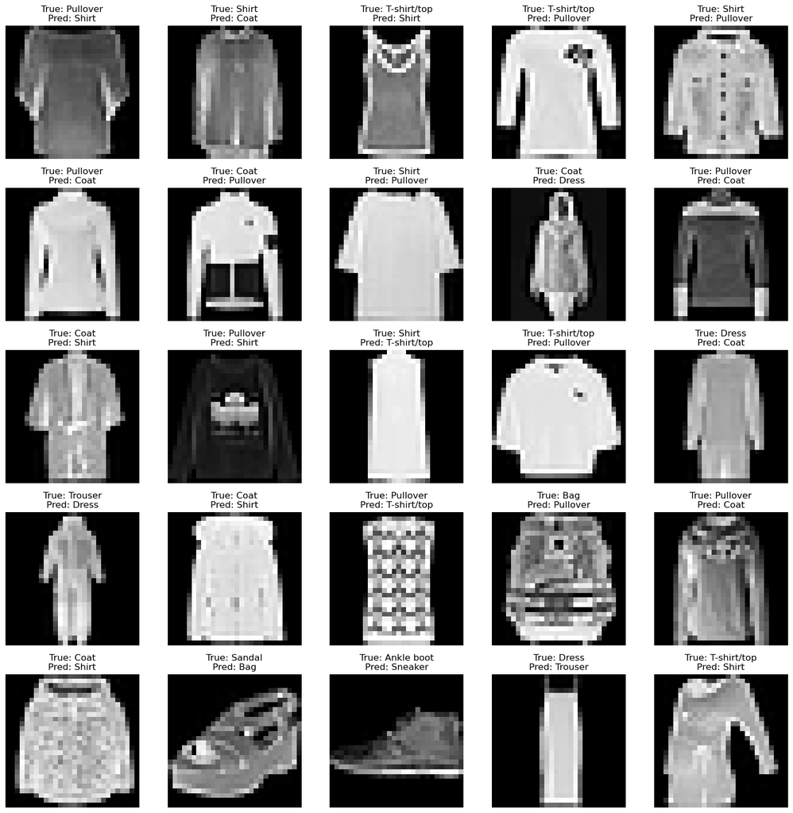

```
313/313 ━━━━━━━━━━━━━━━━━━━━ 1s 2ms/step
Model 2 - Accuracy: 0.8694, Precision: 0.8711, Recall: 0.8694, F1 Score: 0.8674
Incorrect Predictions for Model 2: 1306
313/313 ━━━━━━━━━━━━━━━━━━━━ 1s 2ms/step
```

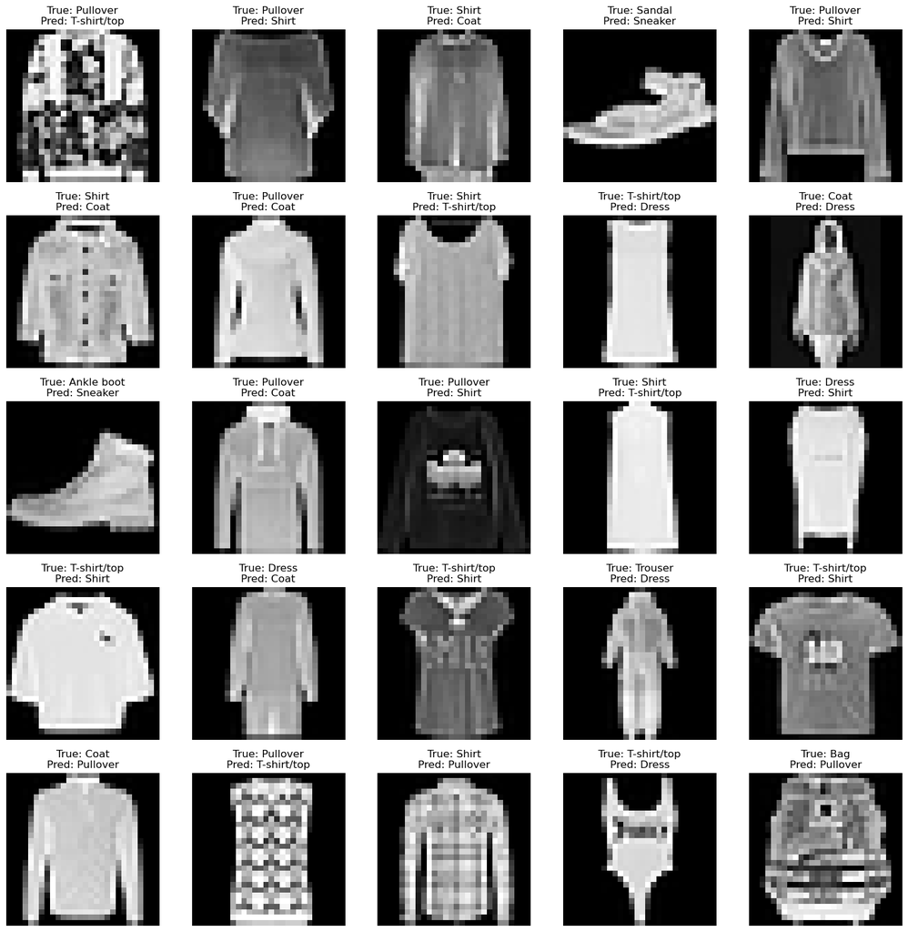

```
313/313 ━━━━━━━━━━━━━━━━━━━━ 1s 2ms/step
Model 3 - Accuracy: 0.3852, Precision: 0.3132, Recall: 0.3852, F1 Score: 0.3080
Incorrect Predictions for Model 3: 6148
 34/313 ━━━━━━━━━━━━━━━━━━━━ 0s 2ms/step
```

```
313/313 ━━━━━━━━━━━━━━━━━━━━ 1s 2ms/step
```

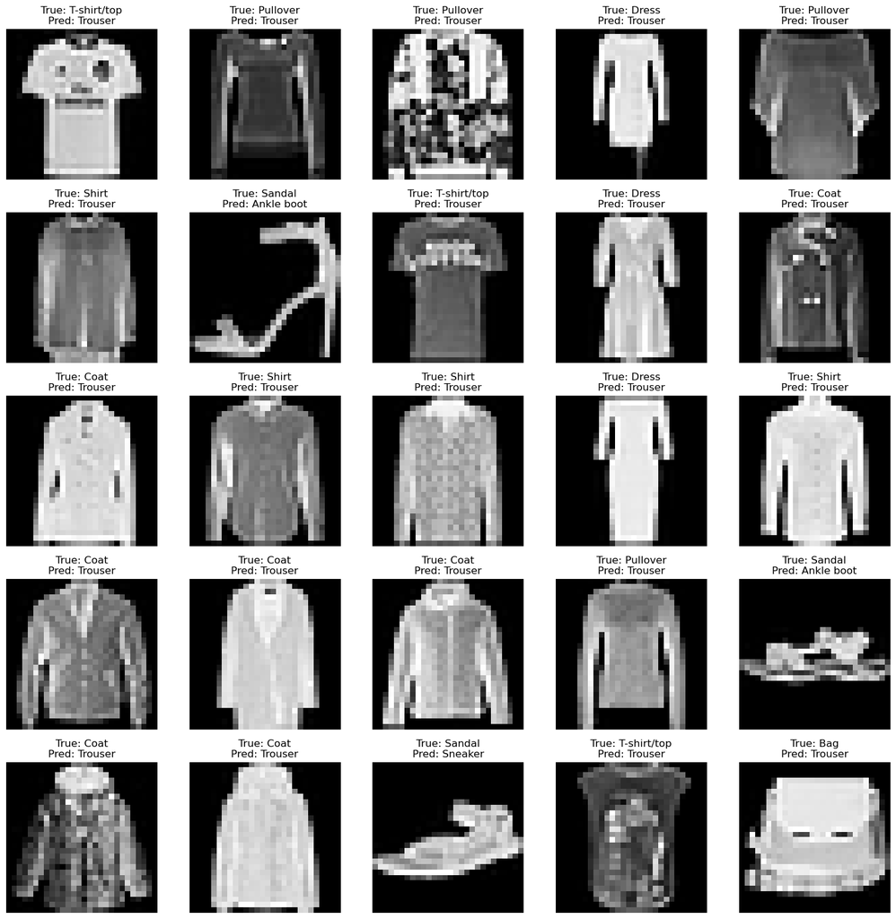

```python
def evaluate_model(model, X_test, y_test, class_names):
    y_pred_prob = model.predict(X_test)
    y_pred = np.argmax(y_pred_prob, axis=1)
    accuracy = accuracy_score(y_test, y_pred)
    precision = precision_score(y_test, y_pred, average='weighted')
    recall = recall_score(y_test, y_pred, average='weighted')
    f1 = f1_score(y_test, y_pred, average='weighted')
    incorrect_indices = [i for i in range(len(y_test)) if y_test[i] != y_pred[i]]
    return accuracy, precision, recall, f1, incorrect_indices

# Error analysis
for i, (model, weights) in enumerate(zip([model1, model2, model3], [best_weights1, best_weights2, best_weights3]), start=1):
    accuracy, precision, recall, f1, incorrect_indices = evaluate_model(model, X_test_flat, y_test, class_names)
    print(f"Model {i} - Accuracy: {accuracy:.4f}, Precision: {precision:.4f}, Recall: {recall:.4f}, F1 Score: {f1:.4f}")
    print(f"Incorrect Predictions for Model {i}: {len(incorrect_indices)}")

# image displaying
    num_samples = min(25, len(incorrect_indices))
    y_pred_prob = model.predict(X_test_flat)
    y_pred = np.argmax(y_pred_prob, axis=1)
    fig, axs = plt.subplots(5, 5, figsize=(15, 15))
    for j, index in enumerate(incorrect_indices[:num_samples]):
        row = j // 5
        col = j % 5
        axs[row, col].imshow(X_test_flat[index].reshape(28, 28), cmap='gray')
        axs[row, col].axis('off')
        axs[row, col].set_title(f"True: {class_names[y_test[index]]}\nPred: {class_names[y_pred[index]]}")
    plt.tight_layout()
    plt.show()
```

Model 3's performance is significantly lower than the earlier versions; it has incredibly low recall, accuracy, precision, and F1 scores.

As in the terms of Epoch I will be when the value validation would be at 10 in the model Loss. That would be the best point.

*Conclusion*

Model 1 is the most suitable option of the three models based on the evaluation metrics and views. Its superior performance in identifying the test data over the other models is evidenced by its greater accuracy, precision, recall, and F1 score.

```python
from keras.callbacks import ModelCheckpoint
from tensorflow.keras.models import load_model
```

```python
tf.saved_model.save(model, '/Users/lakshay/Desktop/LAB_ALL/CSCN8010-Lab-8888349/Percet_model.keras')
```

```
INFO:tensorflow:Assets written to: /Users/lakshay/Desktop/LAB_ALL/CSCN8010-Lab-8888349/Percet_model.keras/assets
```

```
INFO:tensorflow:Assets written to: /Users/lakshay/Desktop/LAB_ALL/CSCN8010-Lab-8888349/Percet_model.keras/assets
```

Referances for the code and for understanding

https://www.kaggle.com/code/abhishekyana/fmnist-dataset-with-cnns-tensorflow/notebook

https://github.com/CSCN8010/CSCN8010/blob/main/dl_class_notebooks/03A_minimal_mnist_keras.ipynb

https://github.com/CSCN8010/CSCN8010/blob/main/class_notebooks/datasets/mnist.ipynb

https://github.com/CSCN8010/CSCN8010/blob/main/dl_class_notebooks/03D_keras_checkpoints_save_model.ipynb